# p8106 midterm

Mirah

2024-03-31

# Midterm Project

### background

```r
#loading data set

load("Data/recovery.RData")

dat = dat %>% drop_na() %>% janitor::clean_names() %>% select(-id)

#no missing values
```

##Exploratory Analysis

Splitting up the data into a matrix of predictors and a vector of responses.

```r
#matrix of predictors, no recovery time
x_ea = model.matrix(recovery_time ~., dat)[, -1]
#vector of responses
y_ea = dat$recovery_time

data_ea = dat %>%
  mutate(
    gender = case_match(
      gender,
      1 ~ "Male",
      0 ~ "Female"
    ),
    race = case_match(
      race,
      "1" ~ "White, non-Hispanic",
      "2" ~ "Asian",
      "3" ~ "Black, non-Hispanic",
      "4" ~ "Hispanic"
    ),
    smoking = case_match(
      smoking,
      "0" ~ "No history",
      "1" ~ "Formerly smoked",
      "2" ~ "Currently smokes"
    ),
    hypertension = case_match(
      hypertension,
      1 ~ "Hypertension",
      0 ~ "No hypertension"
    ),
    diabetes = case_match(
      diabetes,
      1 ~ "Diabetes",
      0 ~ "No diabetes"
    ),
    vaccine = case_match(
      vaccine,
      1 ~ "Vaccinated",
      0 ~ "Not vaccinated"
    ),
    severity = case_match(
      severity,
      1 ~ "Severe infection",
      0 ~ "Not severe infection"
    )
  )
```

Creating a summary statistic table:

```r
skimr::skim(data_ea) %>%  dplyr::mutate(across(where(is.numeric), ~round(., 2))) %>%  select(skim_variable, numeric.hist, n_missing, numeric.mean, numeric.sd, numeric.p0, numeric.p50, numeric.p100) %>% knitr::kable()
```

| skim_variable | numeric.hist | n_missing | numeric.mean | numeric.sd | numeric.p0 | numeric.p50 | numeric.p100 |
| --- | --- | --- | --- | --- | --- | --- | --- |
| gender | NA | 0 | NA | NA | NA | NA | NA |
| race | NA | 0 | NA | NA | NA | NA | NA |
| smoking | NA | 0 | NA | NA | NA | NA | NA |
| hypertension | NA | 0 | NA | NA | NA | NA | NA |
| diabetes | NA | 0 | NA | NA | NA | NA | NA |
| vaccine | NA | 0 | NA | NA | NA | NA | NA |
| severity | NA | 0 | NA | NA | NA | NA | NA |
| study | NA | 0 | NA | NA | NA | NA | NA |
| age | ▁▂▇▂▁ | 0 | 60.20 | 4.48 | 42.0 | 60.00 | 79.0 |
| height | ▁▂▇▅▁ | 0 | 169.90 | 5.97 | 147.8 | 169.90 | 188.6 |
| weight | ▁▃▇▃▁ | 0 | 79.96 | 7.14 | 55.9 | 79.80 | 103.7 |
| bmi | ▁▆▇▂▁ | 0 | 27.76 | 2.79 | 18.8 | 27.65 | 38.9 |
| sbp | ▁▃▇▅▁ | 0 | 130.47 | 7.97 | 105.0 | 130.00 | 156.0 |
| ldl | ▁▂▇▅▁ | 0 | 110.45 | 19.76 | 28.0 | 110.00 | 178.0 |
| recovery_time | ▇▁▁▁▁ | 0 | 42.17 | 23.15 | 2.0 | 39.00 | 365.0 |

```r
exploratory_table = table1(~ gender + age + race + height + weight + bmi + sbp + ldl + smoking + hypertension + diabetes + severity + recovery_time |study, data=data_ea)

exploratory_table
```

|  | A (N=2000) | B (N=1000) | Overall (N=3000) |
| --- | --- | --- | --- |
| gender |  |  |  |
| Female | 1036 (51.8%) | 508 (50.8%) | 1544 (51.5%) |
| Male | 964 (48.2%) | 492 (49.2%) | 1456 (48.5%) |
| age |  |  |  |
| Mean (SD) | 60.2 (4.53) | 60.2 (4.38) | 60.2 (4.48) |
| Median [Min, Max] | 60.0 [42.0, 79.0] | 60.0 [45.0, 77.0] | 60.0 [42.0, 79.0] |
| race |  |  |  |
| Asian | 108 (5.4%) | 50 (5.0%) | 158 (5.3%) |
| Black, non-Hispanic | 408 (20.4%) | 196 (19.6%) | 604 (20.1%) |
| Hispanic | 172 (8.6%) | 99 (9.9%) | 271 (9.0%) |
| White, non-Hispanic | 1312 (65.6%) | 655 (65.5%) | 1967 (65.6%) |
| height |  |  |  |
| Mean (SD) | 170 (5.95) | 170 (6.01) | 170 (5.97) |
| Median [Min, Max] | 170 [148, 189] | 170 [148, 189] | 170 [148, 189] |
| weight |  |  |  |
| Mean (SD) | 79.9 (7.13) | 80.0 (7.16) | 80.0 (7.14) |
| Median [Min, Max] | 79.6 [55.9, 104] | 80.0 [58.4, 99.4] | 79.8 [55.9, 104] |
| bmi |  |  |  |
| Mean (SD) | 27.8 (2.77) | 27.8 (2.85) | 27.8 (2.79) |
| Median [Min, Max] | 27.7 [18.8, 36.7] | 27.6 [19.2, 38.9] | 27.7 [18.8, 38.9] |
| sbp |  |  |  |
| Mean (SD) | 131 (8.02) | 130 (7.88) | 130 (7.97) |
| Median [Min, Max] | 131 [105, 156] | 130 [105, 155] | 130 [105, 156] |
| ldl |  |  |  |
| Mean (SD) | 110 (19.8) | 111 (19.8) | 110 (19.8) |
| Median [Min, Max] | 110 [28.0, 178] | 110 [53.0, 169] | 110 [28.0, 178] |
| smoking |  |  |  |
| Currently smokes | 218 (10.9%) | 101 (10.1%) | 319 (10.6%) |
| Formerly smoked | 557 (27.9%) | 302 (30.2%) | 859 (28.6%) |
| No history | 1225 (61.3%) | 597 (59.7%) | 1822 (60.7%) |
| hypertension |  |  |  |
| Hypertension | 1002 (50.1%) | 490 (49.0%) | 1492 (49.7%) |
| No hypertension | 998 (49.9%) | 510 (51.0%) | 1508 (50.3%) |
| diabetes |  |  |  |
| Diabetes | 322 (16.1%) | 141 (14.1%) | 463 (15.4%) |
| No diabetes | 1678 (83.9%) | 859 (85.9%) | 2537 (84.6%) |
| severity |  |  |  |
| Not severe infection | 1785 (89.3%) | 894 (89.4%) | 2679 (89.3%) |
| Severe infection | 215 (10.8%) | 106 (10.6%) | 321 (10.7%) |
| recovery_time |  |  |  |
| Mean (SD) | 40.4 (11.2) | 45.7 (36.6) | 42.2 (23.2) |
| Median [Min, Max] | 40.0 [10.0, 113] | 37.0 [2.00, 365] | 39.0 [2.00, 365] |

Scatterplots of numeric variables and recovery_time:

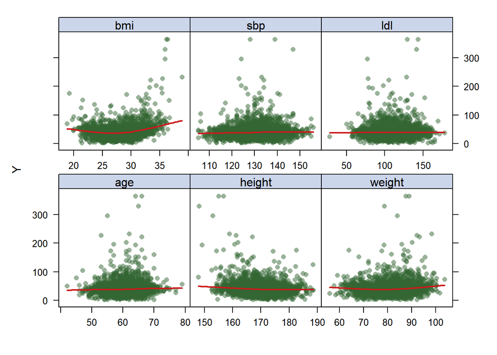

```r
theme1 <- trellis.par.get()
theme1$plot.symbol$col <- rgb(.2, .4, .2, .5)
theme1$plot.symbol$pch <- 16
theme1$plot.line$col <- rgb(.8, .1, .1, 1)
theme1$plot.line$lwd <- 2
theme1$strip.background$col <- rgb(.0, .2, .6, .2)
trellis.par.set(theme1)

featurePlot(x_ea[, -c(2,3,4,5,6,7,11,12,15,16,17)], y_ea, plot="scatter", labels = c("", "Y"),type = c("p", "smooth"), layout = c(3,2))
```

Scatter plots don’t show much of a trend. Bmi looks slightly parabolic. The rest are slightly linear.

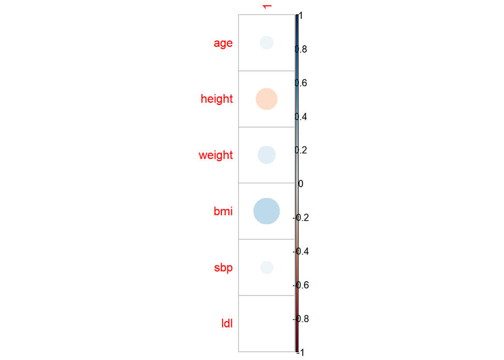

```r
correlation = corrplot(cor(x_ea[, -c(2,3,4,5,6,7,11,12,15,16,17)],y_ea))
```

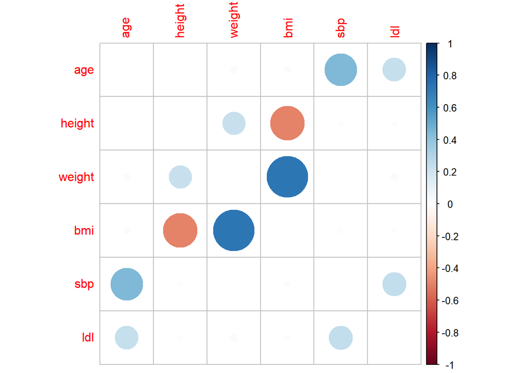

```r
#correlation values and scatter plots show no linear correlations with the nummeric variables

#checking to see if predictors correlate
corrplot(cor(x_ea[, -c(2,3,4,5,6,7,11,12,15,16,17)]), type = "full", diag= FALSE)
```

Correlation plot supports that there is little relationship between predictors and the outcome.

Based on a discussion with the team, we decided to remove outliers and then proceed with further exploratory analysis and model training.

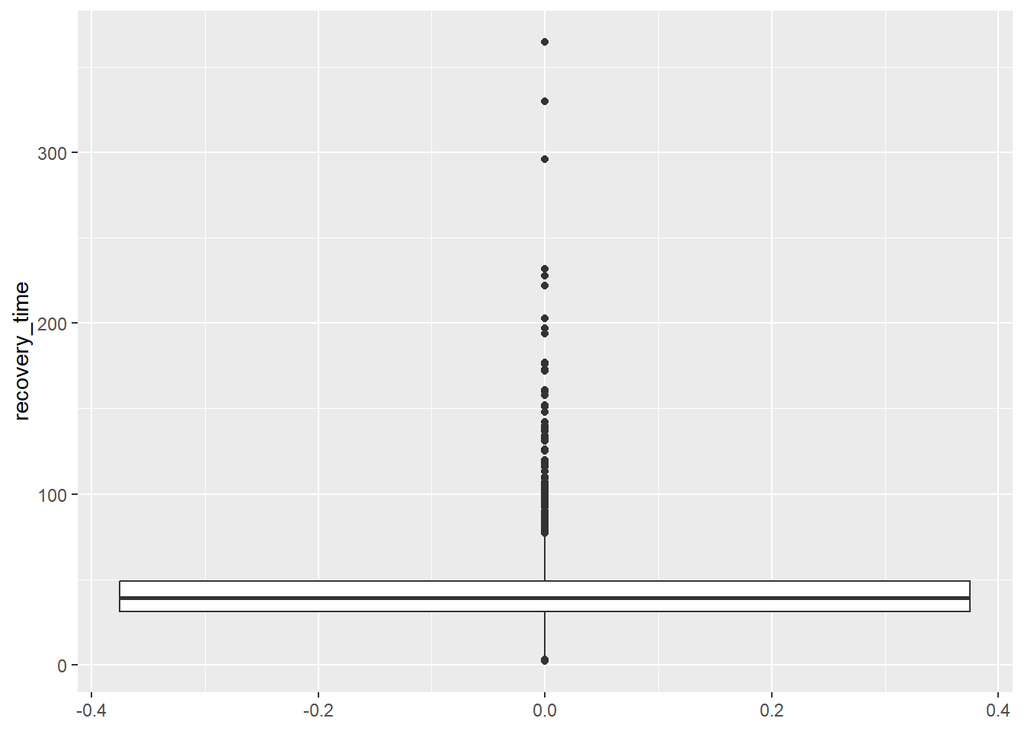

```r
#box plots to show outliers
ggplot(data = dat, mapping = aes(y=recovery_time)) + geom_boxplot()
```

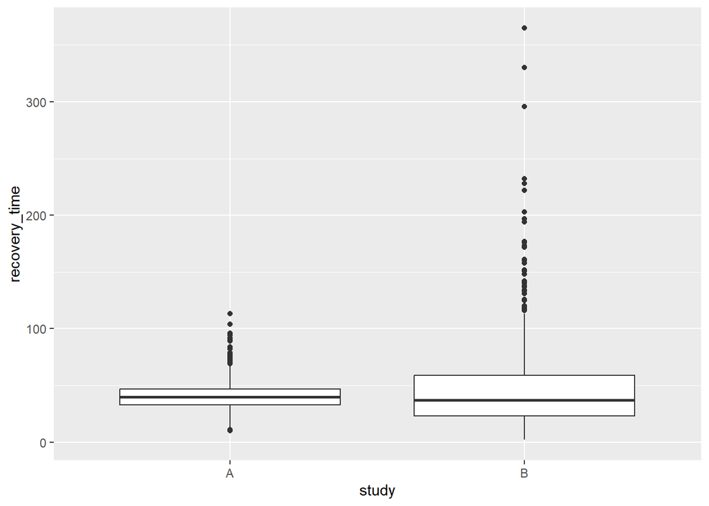

```r
ggplot(data = dat, mapping = aes( x = study, y = recovery_time)) + geom_boxplot()
```

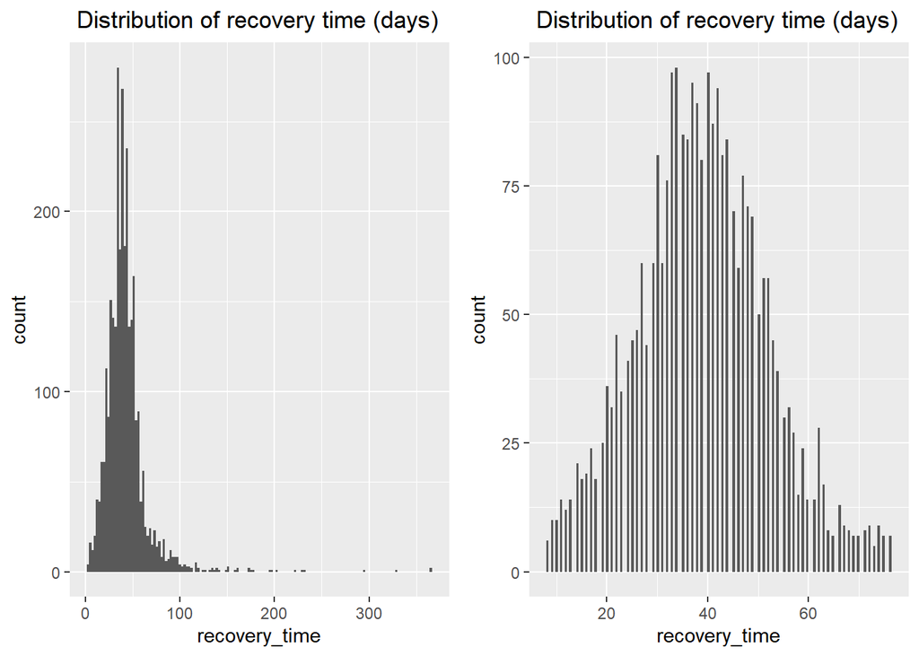

```r
#histogram
hist1 = dat %>%
  ggplot(aes(x = recovery_time)) +
  geom_histogram(bins = 150)+
  labs(title = " Distribution of recovery time (days)")

#skewed

#Removing outliers

outlier_coef = 1.5

outlier_upper = mean(dat$recovery_time) +outlier_coef* sd(dat$recovery_time)

outlier_lower = mean(dat$recovery_time) -outlier_coef* sd(dat$recovery_time)

dat_2 = dat %>%
  filter(outlier_lower < recovery_time & recovery_time < outlier_upper)

#new histogram

hist2 = dat_2 %>%
  ggplot(aes(x = recovery_time)) +
  geom_histogram(bins = 150)+
  labs(title = " Distribution of recovery time (days)")


#looks way more normal

#to compare side by side
gridExtra::grid.arrange(hist1, hist2, nrow=1)
```

Histograms and box plots above show outliers. Histograms above show how the skew was reduced when outliers were removed.

```r
#exploratory plots now that outliers are gone:

skimr::skim(dat_2) %>%  dplyr::mutate(across(where(is.numeric), ~round(., 2))) %>%  select(skim_variable, numeric.hist, n_missing, numeric.mean, numeric.sd, numeric.p0, numeric.p50, numeric.p100) %>% knitr::kable()
```

| skim_variable | numeric.hist | n_missing | numeric.mean | numeric.sd | numeric.p0 | numeric.p50 | numeric.p100 |
| --- | --- | --- | --- | --- | --- | --- | --- |
| study | NA | 0 | NA | NA | NA | NA | NA |
| race | NA | 0 | NA | NA | NA | NA | NA |
| smoking | NA | 0 | NA | NA | NA | NA | NA |
| age | ▁▂▇▂▁ | 0 | 60.15 | 4.48 | 42.0 | 60.0 | 79.0 |
| gender | ▇▁▁▁▇ | 0 | 0.49 | 0.50 | 0.0 | 0.0 | 1.0 |
| height | ▁▅▇▃▁ | 0 | 170.04 | 5.82 | 152.6 | 170.0 | 188.6 |
| weight | ▁▃▇▃▁ | 0 | 79.78 | 7.03 | 55.9 | 79.6 | 103.7 |
| bmi | ▁▃▇▃▁ | 0 | 27.64 | 2.64 | 18.8 | 27.6 | 36.4 |
| hypertension | ▇▁▁▁▇ | 0 | 0.49 | 0.50 | 0.0 | 0.0 | 1.0 |
| diabetes | ▇▁▁▁▂ | 0 | 0.16 | 0.36 | 0.0 | 0.0 | 1.0 |
| sbp | ▁▃▇▅▁ | 0 | 130.40 | 7.96 | 105.0 | 130.0 | 156.0 |
| ldl | ▁▂▇▅▁ | 0 | 110.46 | 19.71 | 28.0 | 110.0 | 178.0 |
| vaccine | ▅▁▁▁▇ | 0 | 0.61 | 0.49 | 0.0 | 1.0 | 1.0 |
| severity | ▇▁▁▁▁ | 0 | 0.10 | 0.30 | 0.0 | 0.0 | 1.0 |
| recovery_time | ▂▆▇▃▁ | 0 | 38.92 | 12.99 | 8.0 | 39.0 | 76.0 |

```r
exploratory_table = table1(~ gender + age + race + height + weight + bmi + sbp + ldl + smoking + hypertension + diabetes + severity + recovery_time |study, data=dat_2)

exploratory_table
```

|  | A (N=1984) | B (N=842) | Overall (N=2826) |
| --- | --- | --- | --- |
| gender |  |  |  |
| Mean (SD) | 0.483 (0.500) | 0.502 (0.500) | 0.489 (0.500) |
| Median [Min, Max] | 0 [0, 1.00] | 1.00 [0, 1.00] | 0 [0, 1.00] |
| age |  |  |  |
| Mean (SD) | 60.2 (4.52) | 60.1 (4.36) | 60.2 (4.48) |
| Median [Min, Max] | 60.0 [42.0, 79.0] | 60.0 [46.0, 77.0] | 60.0 [42.0, 79.0] |
| race |  |  |  |
| 1 | 1300 (65.5%) | 552 (65.6%) | 1852 (65.5%) |
| 2 | 108 (5.4%) | 42 (5.0%) | 150 (5.3%) |
| 3 | 404 (20.4%) | 162 (19.2%) | 566 (20.0%) |
| 4 | 172 (8.7%) | 86 (10.2%) | 258 (9.1%) |
| height |  |  |  |
| Mean (SD) | 170 (5.88) | 170 (5.65) | 170 (5.82) |
| Median [Min, Max] | 170 [153, 189] | 170 [153, 188] | 170 [153, 189] |
| weight |  |  |  |
| Mean (SD) | 79.9 (7.07) | 79.6 (6.92) | 79.8 (7.03) |
| Median [Min, Max] | 79.6 [55.9, 104] | 79.7 [58.4, 98.5] | 79.6 [55.9, 104] |
| bmi |  |  |  |
| Mean (SD) | 27.7 (2.69) | 27.5 (2.50) | 27.6 (2.64) |
| Median [Min, Max] | 27.7 [18.8, 36.4] | 27.4 [20.9, 35.2] | 27.6 [18.8, 36.4] |
| sbp |  |  |  |
| Mean (SD) | 131 (8.02) | 130 (7.82) | 130 (7.96) |
| Median [Min, Max] | 130 [105, 156] | 130 [105, 154] | 130 [105, 156] |
| ldl |  |  |  |
| Mean (SD) | 110 (19.7) | 111 (19.6) | 110 (19.7) |
| Median [Min, Max] | 110 [28.0, 178] | 111 [53.0, 165] | 110 [28.0, 178] |
| smoking |  |  |  |
| 0 | 1217 (61.3%) | 513 (60.9%) | 1730 (61.2%) |
| 1 | 552 (27.8%) | 246 (29.2%) | 798 (28.2%) |
| 2 | 215 (10.8%) | 83 (9.9%) | 298 (10.5%) |
| hypertension |  |  |  |
| Mean (SD) | 0.499 (0.500) | 0.477 (0.500) | 0.493 (0.500) |
| Median [Min, Max] | 0 [0, 1.00] | 0 [0, 1.00] | 0 [0, 1.00] |
| diabetes |  |  |  |
| Mean (SD) | 0.161 (0.368) | 0.141 (0.349) | 0.155 (0.362) |
| Median [Min, Max] | 0 [0, 1.00] | 0 [0, 1.00] | 0 [0, 1.00] |
| severity |  |  |  |
| Mean (SD) | 0.108 (0.310) | 0.0914 (0.288) | 0.103 (0.304) |
| Median [Min, Max] | 0 [0, 1.00] | 0 [0, 1.00] | 0 [0, 1.00] |
| recovery_time |  |  |  |
| Mean (SD) | 40.0 (10.3) | 36.3 (17.5) | 38.9 (13.0) |
| Median [Min, Max] | 40.0 [10.0, 75.0] | 33.0 [8.00, 76.0] | 39.0 [8.00, 76.0] |

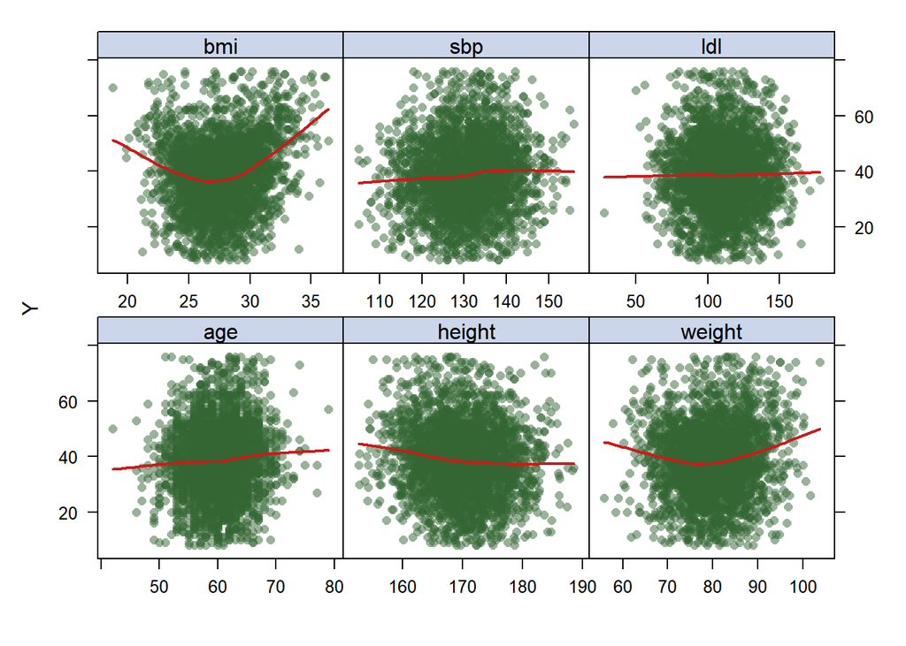

```r
#scatter plot
#matrix of predictors, no recovery time
x_ea2 = model.matrix(recovery_time ~., dat_2)[, -1]
#vector of responses
y_ea2 = dat_2$recovery_time
theme1 <- trellis.par.get()
theme1$plot.symbol$col <- rgb(.2, .4, .2, .5)
theme1$plot.symbol$pch <- 16
theme1$plot.line$col <- rgb(.8, .1, .1, 1)
theme1$plot.line$lwd <- 2
theme1$strip.background$col <- rgb(.0, .2, .6, .2)
trellis.par.set(theme1)

featurePlot(x_ea2[, -c(2,3,4,5,6,7,11,12,15,16,17)], y_ea2, plot="scatter", labels = c("", "Y"),type = c("p", "smooth"), layout = c(3,2))
```

##Model training

```r
#splitting data into training and testing
set.seed(1234)

#data partition
data_split = initial_split(data = dat_2, prop = .8)

training_data = training(data_split)
test_data = testing(data_split) %>% as.vector()
```